# AutoML

**Scenario**

A financial institution faces an increase in loan defaults and wants to mitigate risks by improving its loan approval process. The goal is to develop a strong model is needed to predict the likelihood of loan default and avoid applications prone to default. The model’s performance will directly impact the financial institution's bottom line. The financial goal is to help the institution to make more informed lending decisions, minimizing losses and improving profitability.

**Learning objectives**

- You have built a model using H2O. In this assignment you will enhance the top variables from your previous model. You will perform the appropriate process so your model can really be deployable.
- Notice the sequence in the process when you do the sampling and feature engineering

## (0) Import libraries

```python
#!pip install scikit-learn pandas numpy matplotlib seaborn plotly pycaret category_encoders h2o sweetbviz imblearn
```

```python
# data
import pandas as pd
import numpy as np

# visualization
import matplotlib as mpl
import matplotlib.pyplot as plt
%matplotlib inline
import seaborn as sns
#import missingno as msno
import plotly.express as px
import plotly.figure_factory as ff
import plotly.graph_objects as go
#from wordcloud import WordCloud

from sklearn import datasets
from sklearn.tree import plot_tree
from sklearn.tree import DecisionTreeClassifier
from sklearn.model_selection import train_test_split
from sklearn.metrics import accuracy_score

# styling
%matplotlib inline
sns.set_style('darkgrid')
mpl.rcParams['font.size'] = 12
mpl.rcParams['figure.facecolor'] = '#00000000'
mpl.rcParams['font.size'] = 12
mpl.rcParams['figure.facecolor'] = '#00000000'

import os
#from wordcloud import WordCloud
import sweetviz
import warnings
warnings.filterwarnings("ignore")
```

## (1) Load Data

- Use pandas to load the dataset (the provided .csv file).

```python
path = '/Users/chriskuo/Downloads/data'
data =  pd.read_csv(path + "/cu_dtree_lecture.csv")
columns = ['TARGET','APARTMENTS_MODE', 'CODE_GENDER', 'DAYS_BIRTH', 'DAYS_ID_PUBLISH',
    'DAYS_LAST_PHONE_CHANGE', 'EMERGENCYSTATE_MODE', 'ENTRANCES_AVG',
    'EXT_SOURCE_1', 'EXT_SOURCE_2', 'EXT_SOURCE_3', 'FLAG_OWN_CAR',
    'FLAG_OWN_REALTY', 'FLOORSMAX_AVG', 'FONDKAPREMONT_MODE',
    'HOUSETYPE_MODE', 'LIVINGAPARTMENTS_MODE', 'NAME_CONTRACT_TYPE',
    'NAME_EDUCATION_TYPE', 'NAME_FAMILY_STATUS', 'NAME_HOUSING_TYPE',
    'NAME_INCOME_TYPE', 'NAME_TYPE_SUITE', 'OCCUPATION_TYPE',
    'ORGANIZATION_TYPE', 'OWN_CAR_AGE', 'WALLSMATERIAL_MODE',
    'WEEKDAY_APPR_PROCESS_START', 'YEARS_BUILD_AVG',
    'YEARS_BUILD_MEDI', 'YEARS_BUILD_MODE']
data = data[columns]
data.info()
```

```
<class 'pandas.core.frame.DataFrame'>
RangeIndex: 307511 entries, 0 to 307510
Data columns (total 31 columns):
 #   Column                      Non-Null Count   Dtype
---  ------                      --------------   -----
 0   TARGET                      307511 non-null  int64
 1   APARTMENTS_MODE             151450 non-null  float64
 2   CODE_GENDER                 307511 non-null  object
 3   DAYS_BIRTH                  307511 non-null  int64
 4   DAYS_ID_PUBLISH             307511 non-null  int64
 5   DAYS_LAST_PHONE_CHANGE      307510 non-null  float64
 6   EMERGENCYSTATE_MODE         161756 non-null  object
 7   ENTRANCES_AVG               152683 non-null  float64
 8   EXT_SOURCE_1                134133 non-null  float64
 9   EXT_SOURCE_2                306851 non-null  float64
```

[output cut: 23 more lines]

```python
data.info()
```

```
<class 'pandas.core.frame.DataFrame'>
RangeIndex: 307511 entries, 0 to 307510
Data columns (total 31 columns):
 #   Column                      Non-Null Count   Dtype
---  ------                      --------------   -----
 0   TARGET                      307511 non-null  int64
 1   APARTMENTS_MODE             151450 non-null  float64
 2   CODE_GENDER                 307511 non-null  object
 3   DAYS_BIRTH                  307511 non-null  int64
 4   DAYS_ID_PUBLISH             307511 non-null  int64
 5   DAYS_LAST_PHONE_CHANGE      307510 non-null  float64
 6   EMERGENCYSTATE_MODE         161756 non-null  object
 7   ENTRANCES_AVG               152683 non-null  float64
 8   EXT_SOURCE_1                134133 non-null  float64
 9   EXT_SOURCE_2                306851 non-null  float64
```

[output cut: 23 more lines]

```python
cat_var = [
'CODE_GENDER',
'EMERGENCYSTATE_MODE',
'FLAG_OWN_CAR',
'FLAG_OWN_REALTY',
'FONDKAPREMONT_MODE',
'HOUSETYPE_MODE',
'NAME_CONTRACT_TYPE',
'NAME_EDUCATION_TYPE',
'NAME_FAMILY_STATUS',
'NAME_HOUSING_TYPE',
'NAME_INCOME_TYPE',
'NAME_TYPE_SUITE',
'OCCUPATION_TYPE',
'ORGANIZATION_TYPE',
'WALLSMATERIAL_MODE',
'WEEKDAY_APPR_PROCESS_START']

num_var = ['APARTMENTS_MODE',
'DAYS_LAST_PHONE_CHANGE',
'ENTRANCES_AVG',
'EXT_SOURCE_1',
'EXT_SOURCE_2',
'EXT_SOURCE_3',
'FLOORSMAX_AVG',
'LIVINGAPARTMENTS_MODE',
'OWN_CAR_AGE',
'YEARS_BUILD_AVG',
'YEARS_BUILD_MEDI',
'YEARS_BUILD_MODE',
'DAYS_BIRTH',
'DAYS_ID_PUBLISH']

X_vars = cat_var + num_var
target='TARGET'
```

```python
data[target].value_counts()
```

```
TARGET
0    282686
1     24825
Name: count, dtype: int64
```

## (2) Data preparation

```python
# Your code to split the data
X = data.drop(target, axis=1)
y = data[target]

from sklearn.model_selection import train_test_split
X_train, X_test, y_train, y_test = train_test_split(X, y, random_state=0)
train, test= train_test_split(data, random_state=0)
[X_train.shape,X_test.shape, y_train.shape, y_test.shape]
```

```
[(230633, 30), (76878, 30), (230633,), (76878,)]
```

```python
# https://github.com/fbdesignpro/sweetviz

import sweetviz as sv

my_report = sv.analyze(train)
my_report.show_html() # Default arguments will generate to "SWEETVIZ_REPORT.html"
```

```
                                             |          | [  0%]   00:00 -> (? left)
```

```
Report SWEETVIZ_REPORT.html was generated! NOTEBOOK/COLAB USERS: the web browser MAY not pop up, regardless, the report IS saved in your notebook/colab files.
```

```python
my_report = sv.analyze(train, target_feat=target)
my_report.show_html('report.html')
my_report.show_notebook()
```

```
                                             |          | [  0%]   00:00 -> (? left)
```

```
Report report.html was generated! NOTEBOOK/COLAB USERS: the web browser MAY not pop up, regardless, the report IS saved in your notebook/colab files.
```

[interactive chart not shown]

### (2.1) Feature enhancement for the categorical variables - Target/mean encoding

```python
# Show the code to use "target_encoder" for mean encoding
# Create a new set of mean-encoded variables for the categorical variables
# Use the X-train to get the mean first then apply to the test data.

from category_encoders import target_encoder as te
ec = te.TargetEncoder()

X_train_m = pd.DataFrame()
X_test_m = pd.DataFrame()

for var in cat_var:
    X_train_m[var+'_D'] = ec.fit_transform(X_train[var],y_train)
    X_test_m[var+'_D'] = ec.transform(X_test[var])

X_train_m
```

|  | CODE_GENDER_D | EMERGENCYSTATE_MODE_D | FLAG_OWN_CAR_D | FLAG_OWN_REALTY_D | FONDKAPREMONT_MODE_D | HOUSETYPE_MODE_D | NAME_CONTRACT_TYPE_D | NAME_EDUCATION_TYPE_D | NAME_FAMILY_STATUS_D | NAME_HOUSING_TYPE_D | NAME_INCOME_TYPE_D | NAME_TYPE_SUITE_D | OCCUPATION_TYPE_D | ORGANIZATION_TYPE_D | WALLSMATERIAL_MODE_D | WEEKDAY_APPR_PROCESS_START_D |
| --- | --- | --- | --- | --- | --- | --- | --- | --- | --- | --- | --- | --- | --- | --- | --- | --- |
| 45598 | 0.102103 | 0.070237 | 0.072786 | 0.084154 | 0.070560 | 0.069918 | 0.054960 | 0.089658 | 0.076098 | 0.078225 | 0.075904 | 0.082475 | 0.065393 | 0.065502 | 0.074395 | 0.081649 |
| 155019 | 0.070390 | 0.070237 | 0.072786 | 0.079934 | 0.086537 | 0.091962 | 0.083986 | 0.054169 | 0.076098 | 0.078225 | 0.075904 | 0.082475 | 0.065393 | 0.093993 | 0.091743 | 0.083537 |
| 147473 | 0.070390 | 0.092975 | 0.085577 | 0.079934 | 0.086537 | 0.091962 | 0.083986 | 0.089658 | 0.098841 | 0.078225 | 0.054055 | 0.082475 | 0.065393 | 0.054188 | 0.091743 | 0.081649 |
| 56665 | 0.070390 | 0.092975 | 0.085577 | 0.079934 | 0.086537 | 0.091962 | 0.083986 | 0.088140 | 0.098841 | 0.078225 | 0.075904 | 0.082475 | 0.097494 | 0.102862 | 0.091743 | 0.080661 |
| 32334 | 0.102103 | 0.070237 | 0.085577 | 0.084154 | 0.086537 | 0.069918 | 0.083986 | 0.089658 | 0.076098 | 0.120656 | 0.075904 | 0.077797 | 0.105616 | 0.099099 | 0.074395 | 0.079557 |
| ... | ... | ... | ... | ... | ... | ... | ... | ... | ... | ... | ... | ... | ... | ... | ... | ... |
| 122579 | 0.070390 | 0.070237 | 0.085577 | 0.079934 | 0.070560 | 0.069918 | 0.083986 | 0.089658 | 0.101273 | 0.078225 | 0.075904 | 0.082475 | 0.097494 | 0.093993 | 0.064419 | 0.081649 |
| 304137 | 0.070390 | 0.070237 | 0.085577 | 0.079934 | 0.066549 | 0.069918 | 0.083986 | 0.089658 | 0.076098 | 0.078225 | 0.054055 | 0.082475 | 0.065393 | 0.054188 | 0.068722 | 0.079451 |
| 152315 | 0.102103 | 0.070237 | 0.085577 | 0.084154 | 0.070560 | 0.069918 | 0.054960 | 0.089658 | 0.101273 | 0.078225 | 0.096229 | 0.082475 | 0.107113 | 0.093993 | 0.064419 | 0.079451 |
| 117952 | 0.102103 | 0.092975 | 0.072786 | 0.084154 | 0.086537 | 0.091962 | 0.083986 | 0.089658 | 0.076098 | 0.120656 | 0.096229 | 0.082475 | 0.107113 | 0.102862 | 0.091743 | 0.079557 |
| 305711 | 0.070390 | 0.070237 | 0.085577 | 0.079934 | 0.070560 | 0.069918 | 0.083986 | 0.089658 | 0.076098 | 0.078225 | 0.096229 | 0.082475 | 0.065393 | 0.082086 | 0.077056 | 0.081649 |

230633 rows × 16 columns

### (2.2) Feature enhancement for continuous variables

```python
# https://dataman-ai.medium.com/avoid-these-deadly-modeling-mistakes-that-may-cost-you-a-career-d7c3aae79db1
```

```python
# Let's inspect the data and cut into 5 bins (10 will be fine)
X_train['OWN_CAR_AGE_D'] = pd.qcut(X_train['OWN_CAR_AGE'],5)
X_train['OWN_CAR_AGE_D']
```

```
45598       (7.0, 12.0]
155019    (-0.001, 4.0]
147473              NaN
56665               NaN
32334               NaN
              ...
122579              NaN
304137              NaN
152315              NaN
117952     (12.0, 17.0]
305711              NaN
Name: OWN_CAR_AGE_D, Length: 230633, dtype: category
Categories (5, interval[float64, right]): [(-0.001, 4.0] < (4.0, 7.0] < (7.0, 12.0] < (12.0, 17.0] < (17.0, 91.0]]
```

```python
# In anomaly detection, pay special attention to missing values
X_train['OWN_CAR_AGE_D'] = pd.qcut(X_train['OWN_CAR_AGE'],5,duplicates='drop').cat.add_categories('NoData')
X_train['OWN_CAR_AGE_D'] = X_train['OWN_CAR_AGE_D'].fillna('NoData').astype('str')
X_train['OWN_CAR_AGE_D']
```

```
45598       (7.0, 12.0]
155019    (-0.001, 4.0]
147473           NoData
56665            NoData
32334            NoData
              ...
122579           NoData
304137           NoData
152315           NoData
117952     (12.0, 17.0]
305711           NoData
Name: OWN_CAR_AGE_D, Length: 230633, dtype: object
```

```python
# Get the bins. But we shall add the new category later.
train_bins = pd.qcut(X_train['OWN_CAR_AGE'], q=5, retbins=True)[1]
train_bins
```

```
array([ 0.,  4.,  7., 12., 17., 91.])
```

```python
# In anomaly detection, pay special attention to any special values (here we use -99 and -999 as examples.
# You have to use the one-way plot to make the decision
X_train.loc[X_train['OWN_CAR_AGE_D']==-99, 'OWN_CAR_AGE_D'] = -99
X_train.loc[X_train['OWN_CAR_AGE_D']==-999, 'OWN_CAR_AGE_D'] = -999
```

```python
# In anomaly detection, pay special attention to missing values
X_train['OWN_CAR_AGE_D'] = pd.qcut(X_train['OWN_CAR_AGE'],5,duplicates='drop').cat.add_categories('NoData')
X_train['OWN_CAR_AGE_D'] = X_train['OWN_CAR_AGE_D'].fillna('NoData').astype('str')
X_train['OWN_CAR_AGE_D']
X_train.loc[X_train['OWN_CAR_AGE_D']==-99, 'OWN_CAR_AGE_D'] = -99
X_train.loc[X_train['OWN_CAR_AGE_D']==-999, 'OWN_CAR_AGE_D'] = -999
```

```python
X_train['OWN_CAR_AGE_D'].value_counts()
```

```
OWN_CAR_AGE_D
NoData           152228
(-0.001, 4.0]     18836
(7.0, 12.0]       18123
(12.0, 17.0]      14217
(17.0, 91.0]      14184
(4.0, 7.0]        13045
Name: count, dtype: int64
```

```python
# Apply the same bins to to the test
X_test['OWN_CAR_AGE_D'] = pd.cut(X_test['OWN_CAR_AGE'], bins=train_bins, include_lowest=True)
X_test['OWN_CAR_AGE_D']
```

```
42962               NaN
227307              NaN
290035    (-0.001, 4.0]
239833       (4.0, 7.0]
76427        (4.0, 7.0]
              ...
299074              NaN
63712               NaN
209943              NaN
7914                NaN
166036    (-0.001, 4.0]
Name: OWN_CAR_AGE_D, Length: 76878, dtype: category
Categories (5, interval[float64, right]): [(-0.001, 4.0] < (4.0, 7.0] < (7.0, 12.0] < (12.0, 17.0] < (17.0, 91.0]]
```

```python
# Apply the same bins to to the test
X_test['OWN_CAR_AGE_D'] = pd.cut(X_test['OWN_CAR_AGE'], bins=train_bins, include_lowest=True).cat.add_categories('NoData')
X_test['OWN_CAR_AGE_D'] = X_test['OWN_CAR_AGE_D'].fillna('NoData').astype('str')
X_test.loc[X_test['OWN_CAR_AGE_D']==-99, 'OWN_CAR_AGE_D'] = -99
X_test.loc[X_test['OWN_CAR_AGE_D']==-999, 'OWN_CAR_AGE_D'] = -999
X_test['OWN_CAR_AGE_D']
```

```
42962            NoData
227307           NoData
290035    (-0.001, 4.0]
239833       (4.0, 7.0]
76427        (4.0, 7.0]
              ...
299074           NoData
63712            NoData
209943           NoData
7914             NoData
166036    (-0.001, 4.0]
Name: OWN_CAR_AGE_D, Length: 76878, dtype: object
```

```python
X_test['OWN_CAR_AGE_D'].value_counts()
```

```
OWN_CAR_AGE_D
NoData           50701
(-0.001, 4.0]     6357
(7.0, 12.0]       6008
(12.0, 17.0]      4777
(17.0, 91.0]      4679
(4.0, 7.0]        4356
Name: count, dtype: int64
```

## Now this continous variable has become a categorical variable, can you do target encoding?

## Over-sampling

- Apply the over-sampling strategy on the training data to build the model
- But do not over-sample the test data.
- When you validate your model, you shall use the normal (not oversampled test data)

```python
# Assume your modeling datasets are train_model and test_model
minority = train_model[train_model[target]==1]
majority = train_model[train_model[target]==0]

# Sample with replacement to reach the target
factor = 3 # Make the minority three times
n_to_sample = int(factor * len(minority))
oversampled = minority.sample(n=n_to_sample, replace=True, random_state=42)
print(len(majority), len(minority), len(oversampled))
```

```
211899 18734 56202
```

```python
train_model = pd.concat([majority,oversampled],axis=0)
train_model.shape
```

[output not shown]

## (2) Initialize H2O

```python
import h2o
from h2o.automl import H2OAutoML
# Start H2O cluster
h2o.init()

# Convert to H2O Frame
train_hex = h2o.H2OFrame(train_model)
test_hex = h2o.H2OFrame(test_model)
train_hex[target] = train_hex[target].asfactor() # The target is binary. Make sure it is categorical
test_hex[target] = test_hex[target].asfactor() # The target is binary. Make sure it is categorical
```

```
Checking whether there is an H2O instance running at http://localhost:54321. connected.
Warning: Your H2O cluster version is (4 months) old.  There may be a newer version available.
Please download and install the latest version from: https://h2o-release.s3.amazonaws.com/h2o/latest_stable.html
```

| H2O_cluster_uptime: | 36 mins 09 secs |
| --- | --- |
| H2O_cluster_timezone: | America/New_York |
| H2O_data_parsing_timezone: | UTC |
| H2O_cluster_version: | 3.46.0.7 |
| H2O_cluster_version_age: | 4 months |
| H2O_cluster_name: | H2O_from_python_chriskuo_snj27w |
| H2O_cluster_total_nodes: | 1 |
| H2O_cluster_free_memory: | 1.417 Gb |
| H2O_cluster_total_cores: | 8 |
| H2O_cluster_allowed_cores: | 8 |
| H2O_cluster_status: | locked, healthy |
| H2O_connection_url: | http://localhost:54321 |
| H2O_connection_proxy: | {"http": null, "https": null} |
| H2O_internal_security: | False |
| Python_version: | 3.11.11 final |

```
Parse progress: |████████████████████████████████████████████████████████████████| (done) 100%
Parse progress: |████████████████████████████████████████████████████████████████| (done) 100%
```

## (3) Modeling using H2O

```python
# Use H2O AutoML model to build up to 30 models.
target='TARGET'
# Run AutoML
aml = H2OAutoML(max_models=30, seed=1)
aml.train(y=target, training_frame=train_hex)

# View leaderboard
lb = aml.leaderboard
print(lb)

# Predict
preds = aml.leader.predict(test_hex)
```

```
AutoML progress: |
11:01:17.494: AutoML: XGBoost is not available; skipping it.

██████████████████████████████████████████████████████████████Job request failed Unexpected HTTP error: ('Connection aborted.', BadStatusLine('GET /3/Jobs/$03017f00000132d4ffffffff$_add8fc8487ca09a7ca630e6219c3497e HTTP/1.1\r\n')), will retry after 3s.
█| (done) 100%
model_id                                                      auc    logloss     aucpr    mean_per_class_error      rmse        mse
StackedEnsemble_AllModels_1_AutoML_4_20250728_110117     0.746274   0.25061   0.22993                 0.352618  0.262449  0.0688796
StackedEnsemble_BestOfFamily_1_AutoML_4_20250728_110117  0.745221   0.250975  0.227647                0.355535  0.26264   0.0689799
GBM_5_AutoML_4_20250728_110117                           0.744652   0.251387  0.224515                0.354814  0.262916  0.0691251
GBM_grid_1_AutoML_4_20250728_110117_model_2              0.744433   0.25132   0.226368                0.356055  0.262762  0.0690438
GBM_grid_1_AutoML_4_20250728_110117_model_7              0.744054   0.251486  0.226253                0.352547  0.262815  0.0690717
GBM_2_AutoML_4_20250728_110117                           0.743942   0.251457  0.224954                0.357492  0.262911  0.0691222
GBM_grid_1_AutoML_4_20250728_110117_model_6              0.74335    0.251569  0.226373                0.355773  0.26283   0.0690794
GBM_grid_1_AutoML_4_20250728_110117_model_3              0.743321   0.251576  0.224592                0.352476  0.262908  0.0691206
GBM_grid_1_AutoML_4_20250728_110117_model_9              0.742731   0.251891  0.224757                0.353469  0.262952  0.0691435
GBM_3_AutoML_4_20250728_110117                           0.741759   0.252116  0.222113                0.359629  0.263192  0.0692699
[32 rows x 7 columns]

stackedensemble prediction progress: |███████████████████████████████████████████| (done) 100%
```

```python
# Please provide the code to retrieve one of the top models from H2O
aml.leaderboard.head(30)
```

| model_id | auc | logloss | aucpr | mean_per_class_error | rmse | mse |
| --- | --- | --- | --- | --- | --- | --- |
| StackedEnsemble_AllModels_1_AutoML_4_20250728_110117 | 0.746274 | 0.25061 | 0.22993 | 0.352618 | 0.262449 | 0.0688796 |
| StackedEnsemble_BestOfFamily_1_AutoML_4_20250728_110117 | 0.745221 | 0.250975 | 0.227647 | 0.355535 | 0.26264 | 0.0689799 |
| GBM_5_AutoML_4_20250728_110117 | 0.744652 | 0.251387 | 0.224515 | 0.354814 | 0.262916 | 0.0691251 |
| GBM_grid_1_AutoML_4_20250728_110117_model_2 | 0.744433 | 0.25132 | 0.226368 | 0.356055 | 0.262762 | 0.0690438 |
| GBM_grid_1_AutoML_4_20250728_110117_model_7 | 0.744054 | 0.251486 | 0.226253 | 0.352547 | 0.262815 | 0.0690717 |
| GBM_2_AutoML_4_20250728_110117 | 0.743942 | 0.251457 | 0.224954 | 0.357492 | 0.262911 | 0.0691222 |
| GBM_grid_1_AutoML_4_20250728_110117_model_6 | 0.74335 | 0.251569 | 0.226373 | 0.355773 | 0.26283 | 0.0690794 |
| GBM_grid_1_AutoML_4_20250728_110117_model_3 | 0.743321 | 0.251576 | 0.224592 | 0.352476 | 0.262908 | 0.0691206 |
| GBM_grid_1_AutoML_4_20250728_110117_model_9 | 0.742731 | 0.251891 | 0.224757 | 0.353469 | 0.262952 | 0.0691435 |
| GBM_3_AutoML_4_20250728_110117 | 0.741759 | 0.252116 | 0.222113 | 0.359629 | 0.263192 | 0.0692699 |
| GLM_1_AutoML_4_20250728_110117 | 0.739306 | 0.252895 | 0.215116 | 0.356622 | 0.263622 | 0.0694967 |
| GBM_4_AutoML_4_20250728_110117 | 0.736782 | 0.253715 | 0.21449 | 0.360779 | 0.263944 | 0.0696664 |
| GBM_1_AutoML_4_20250728_110117 | 0.735411 | 0.253452 | 0.218873 | 0.363283 | 0.263561 | 0.0694642 |
| DeepLearning_grid_1_AutoML_4_20250728_110117_model_5 | 0.727975 | 0.256265 | 0.208118 | 0.362006 | 0.26461 | 0.0700183 |
| DeepLearning_1_AutoML_4_20250728_110117 | 0.720259 | 0.25806 | 0.199676 | 0.365364 | 0.265091 | 0.0702733 |
| XRT_1_AutoML_4_20250728_110117 | 0.71897 | 0.258499 | 0.203428 | 0.365124 | 0.265208 | 0.0703354 |
| GBM_grid_1_AutoML_4_20250728_110117_model_4 | 0.71829 | 0.257837 | 0.202449 | 0.359342 | 0.265167 | 0.0703135 |
| DRF_1_AutoML_4_20250728_110117 | 0.71608 | 0.259216 | 0.204169 | 0.368829 | 0.265285 | 0.0703763 |
| GBM_grid_1_AutoML_4_20250728_110117_model_5 | 0.71474 | 0.26097 | 0.195505 | 0.370819 | 0.266555 | 0.0710516 |
| GBM_grid_1_AutoML_4_20250728_110117_model_1 | 0.707542 | 0.26122 | 0.191755 | 0.375698 | 0.266477 | 0.0710101 |
| DeepLearning_grid_1_AutoML_4_20250728_110117_model_2 | 0.699512 | 0.268057 | 0.189781 | 0.374044 | 0.266644 | 0.0710989 |
| DeepLearning_grid_2_AutoML_4_20250728_110117_model_2 | 0.692525 | 0.266167 | 0.165624 | 0.354356 | 0.267923 | 0.0717828 |
| DeepLearning_grid_3_AutoML_4_20250728_110117_model_2 | 0.687115 | 0.26629 | 0.167616 | 0.387838 | 0.268278 | 0.0719731 |
| DeepLearning_grid_1_AutoML_4_20250728_110117_model_3 | 0.670809 | 0.284078 | 0.160369 | 0.387112 | 0.270724 | 0.0732913 |
| DeepLearning_grid_2_AutoML_4_20250728_110117_model_1 | 0.665729 | 0.299861 | 0.155096 | 0.393855 | 0.271263 | 0.0735838 |
| DeepLearning_grid_2_AutoML_4_20250728_110117_model_3 | 0.664884 | 0.276431 | 0.146417 | 0.38632 | 0.269793 | 0.0727883 |
| DeepLearning_grid_3_AutoML_4_20250728_110117_model_1 | 0.66072 | 0.286703 | 0.150974 | 0.402423 | 0.270665 | 0.0732593 |
| DeepLearning_grid_1_AutoML_4_20250728_110117_model_1 | 0.654819 | 0.294038 | 0.139972 | 0.396944 | 0.27118 | 0.0735387 |
| DeepLearning_grid_3_AutoML_4_20250728_110117_model_3 | 0.652404 | 0.27333 | 0.136917 | 0.394423 | 0.270224 | 0.0730212 |
| DeepLearning_grid_2_AutoML_4_20250728_110117_model_4 | 0.647625 | 0.283245 | 0.139417 | 0.402045 | 0.272408 | 0.0742062 |

```
[30 rows x 7 columns]
```

## (4) Select a top model

```python
model_id = 'GBM_5_AutoML_4_20250728_110117'
my_best_model = h2o.get_model(model_id)
my_best_model.summary()
```

Model Summary:

|  | number_of_trees | number_of_internal_trees | model_size_in_bytes | min_depth | max_depth | mean_depth | min_leaves | max_leaves | mean_leaves |
| --- | --- | --- | --- | --- | --- | --- | --- | --- | --- |
|  | 60.0 | 60.0 | 47794.0 | 6.0 | 6.0 | 6.0 | 45.0 | 64.0 | 58.783333 |

```python
# Predict on test data
preds = aml.leader.predict(test_hex)
# Get performance metrics on test set
perf = aml.leader.model_performance(test_hex)
# Print common regression metrics
print("RMSE:", perf.rmse())
#print("MAE :", perf.mae())
print("R2  :", perf.r2())
print("MSE :", perf.mse())
```

```
stackedensemble prediction progress: |███████████████████████████████████████████| (done) 100%
RMSE: 0.25995592749475216
R2  : 0.07367902979728314
MSE : 0.06757708423965685
```

## (5) Save the models

- Create a clean save directory
- Get all models from the leaderboard
- Loop through the leaderboard and save each model

```python
import os
# Create a clean save directory
save_dir = "/Users/chriskuo/Downloads/data/h2o_models/"
os.makedirs(save_dir, exist_ok=True)

# Get all models from the leaderboard
model_ids = list(aml.leaderboard["model_id"].as_data_frame().iloc[:, 0])

# Loop through the leaderboard and save each model
for model_id in model_ids:
    model = h2o.get_model(model_id)
    #save_path = h2o.save_model(model=model, path=save_dir, force=True)
    print(f"Saved model {model_id} to: {save_dir}")
    model_path = h2o.save_model(model=model, path=save_dir, force=True)
```

```
Saved model StackedEnsemble_AllModels_1_AutoML_4_20250728_110117 to: /Users/chriskuo/Downloads/data/h2o_models/
Saved model StackedEnsemble_BestOfFamily_1_AutoML_4_20250728_110117 to: /Users/chriskuo/Downloads/data/h2o_models/
Saved model GBM_5_AutoML_4_20250728_110117 to: /Users/chriskuo/Downloads/data/h2o_models/
Saved model GBM_grid_1_AutoML_4_20250728_110117_model_2 to: /Users/chriskuo/Downloads/data/h2o_models/
Saved model GBM_grid_1_AutoML_4_20250728_110117_model_7 to: /Users/chriskuo/Downloads/data/h2o_models/
Saved model GBM_2_AutoML_4_20250728_110117 to: /Users/chriskuo/Downloads/data/h2o_models/
Saved model GBM_grid_1_AutoML_4_20250728_110117_model_6 to: /Users/chriskuo/Downloads/data/h2o_models/
Saved model GBM_grid_1_AutoML_4_20250728_110117_model_3 to: /Users/chriskuo/Downloads/data/h2o_models/
Saved model GBM_grid_1_AutoML_4_20250728_110117_model_9 to: /Users/chriskuo/Downloads/data/h2o_models/
Saved model GBM_3_AutoML_4_20250728_110117 to: /Users/chriskuo/Downloads/data/h2o_models/
Saved model GLM_1_AutoML_4_20250728_110117 to: /Users/chriskuo/Downloads/data/h2o_models/
Saved model GBM_4_AutoML_4_20250728_110117 to: /Users/chriskuo/Downloads/data/h2o_models/
Saved model GBM_1_AutoML_4_20250728_110117 to: /Users/chriskuo/Downloads/data/h2o_models/
Saved model DeepLearning_grid_1_AutoML_4_20250728_110117_model_5 to: /Users/chriskuo/Downloads/data/h2o_models/
Saved model DeepLearning_1_AutoML_4_20250728_110117 to: /Users/chriskuo/Downloads/data/h2o_models/
Saved model XRT_1_AutoML_4_20250728_110117 to: /Users/chriskuo/Downloads/data/h2o_models/
Saved model GBM_grid_1_AutoML_4_20250728_110117_model_4 to: /Users/chriskuo/Downloads/data/h2o_models/
Saved model DRF_1_AutoML_4_20250728_110117 to: /Users/chriskuo/Downloads/data/h2o_models/
Saved model GBM_grid_1_AutoML_4_20250728_110117_model_5 to: /Users/chriskuo/Downloads/data/h2o_models/
Saved model GBM_grid_1_AutoML_4_20250728_110117_model_1 to: /Users/chriskuo/Downloads/data/h2o_models/
Saved model DeepLearning_grid_1_AutoML_4_20250728_110117_model_2 to: /Users/chriskuo/Downloads/data/h2o_models/
Saved model DeepLearning_grid_2_AutoML_4_20250728_110117_model_2 to: /Users/chriskuo/Downloads/data/h2o_models/
Saved model DeepLearning_grid_3_AutoML_4_20250728_110117_model_2 to: /Users/chriskuo/Downloads/data/h2o_models/
Saved model DeepLearning_grid_1_AutoML_4_20250728_110117_model_3 to: /Users/chriskuo/Downloads/data/h2o_models/
Saved model DeepLearning_grid_2_AutoML_4_20250728_110117_model_1 to: /Users/chriskuo/Downloads/data/h2o_models/
Saved model DeepLearning_grid_2_AutoML_4_20250728_110117_model_3 to: /Users/chriskuo/Downloads/data/h2o_models/
Saved model DeepLearning_grid_3_AutoML_4_20250728_110117_model_1 to: /Users/chriskuo/Downloads/data/h2o_models/
Saved model DeepLearning_grid_1_AutoML_4_20250728_110117_model_1 to: /Users/chriskuo/Downloads/data/h2o_models/
Saved model DeepLearning_grid_3_AutoML_4_20250728_110117_model_3 to: /Users/chriskuo/Downloads/data/h2o_models/
Saved model DeepLearning_grid_2_AutoML_4_20250728_110117_model_4 to: /Users/chriskuo/Downloads/data/h2o_models/
Saved model DeepLearning_grid_3_AutoML_4_20250728_110117_model_4 to: /Users/chriskuo/Downloads/data/h2o_models/
Saved model DeepLearning_grid_1_AutoML_4_20250728_110117_model_4 to: /Users/chriskuo/Downloads/data/h2o_models/
```

## (6) Load the models

- Get leaderboard model IDs in order
- Load models in order

```python
# Get leaderboard model IDs in order
model_ids = aml.leaderboard["model_id"].as_data_frame().iloc[:, 0]

# Load models in order
loaded_models = []
model_dir = "/Users/chriskuo/Downloads/data/h2o_models/"
for model_id in model_ids:
    model_path = os.path.join(model_dir, model_id)
    try:
        model = h2o.load_model(model_path)
        loaded_models.append(model)
        print(f"Loaded: {model.model_id}")
    except Exception as e:
        print(f"Could not load {model_id}: {e}")
```

```
Loaded: StackedEnsemble_AllModels_1_AutoML_4_20250728_110117
Loaded: StackedEnsemble_BestOfFamily_1_AutoML_4_20250728_110117
Loaded: GBM_5_AutoML_4_20250728_110117
Loaded: GBM_grid_1_AutoML_4_20250728_110117_model_2
Loaded: GBM_grid_1_AutoML_4_20250728_110117_model_7
Loaded: GBM_2_AutoML_4_20250728_110117
Loaded: GBM_grid_1_AutoML_4_20250728_110117_model_6
Loaded: GBM_grid_1_AutoML_4_20250728_110117_model_3
Loaded: GBM_grid_1_AutoML_4_20250728_110117_model_9
Loaded: GBM_3_AutoML_4_20250728_110117
Loaded: GLM_1_AutoML_4_20250728_110117
Loaded: GBM_4_AutoML_4_20250728_110117
Loaded: GBM_1_AutoML_4_20250728_110117
Loaded: DeepLearning_grid_1_AutoML_4_20250728_110117_model_5
Loaded: DeepLearning_1_AutoML_4_20250728_110117
Loaded: XRT_1_AutoML_4_20250728_110117
Loaded: GBM_grid_1_AutoML_4_20250728_110117_model_4
Loaded: DRF_1_AutoML_4_20250728_110117
Loaded: GBM_grid_1_AutoML_4_20250728_110117_model_5
Loaded: GBM_grid_1_AutoML_4_20250728_110117_model_1
Loaded: DeepLearning_grid_1_AutoML_4_20250728_110117_model_2
Loaded: DeepLearning_grid_2_AutoML_4_20250728_110117_model_2
Loaded: DeepLearning_grid_3_AutoML_4_20250728_110117_model_2
Loaded: DeepLearning_grid_1_AutoML_4_20250728_110117_model_3
Loaded: DeepLearning_grid_2_AutoML_4_20250728_110117_model_1
Loaded: DeepLearning_grid_2_AutoML_4_20250728_110117_model_3
Loaded: DeepLearning_grid_3_AutoML_4_20250728_110117_model_1
Loaded: DeepLearning_grid_1_AutoML_4_20250728_110117_model_1
Loaded: DeepLearning_grid_3_AutoML_4_20250728_110117_model_3
Loaded: DeepLearning_grid_2_AutoML_4_20250728_110117_model_4
Loaded: DeepLearning_grid_3_AutoML_4_20250728_110117_model_4
Loaded: DeepLearning_grid_1_AutoML_4_20250728_110117_model_4
```

```python
my_model = loaded_models[2]
my_model
```

```
Model Details
=============
H2OGradientBoostingEstimator : Gradient Boosting Machine
Model Key: GBM_5_AutoML_4_20250728_110117
```

Model Summary:

|  | number_of_trees | number_of_internal_trees | model_size_in_bytes | min_depth | max_depth | mean_depth | min_leaves | max_leaves | mean_leaves |
| --- | --- | --- | --- | --- | --- | --- | --- | --- | --- |
|  | 60.0 | 60.0 | 47794.0 | 6.0 | 6.0 | 6.0 | 45.0 | 64.0 | 58.783333 |

```
ModelMetricsBinomial: gbm
** Reported on train data. **

MSE: 0.06656462827183604
RMSE: 0.25800121757820454
LogLoss: 0.24207083679447142
Mean Per-Class Error: 0.34209888587527437
AUC: 0.7708556141786093
AUCPR: 0.2895252100032955
Gini: 0.5417112283572185
```

Confusion Matrix (Act/Pred) for max f1 @ threshold = 0.15860002093646555

|  | 0 | 1 | Error | Rate |
| --- | --- | --- | --- | --- |
| 0 | 191723.0 | 20176.0 | 0.0952 | (20176.0/211899.0) |
| 1 | 11034.0 | 7700.0 | 0.589 | (11034.0/18734.0) |
| Total | 202757.0 | 27876.0 | 0.1353 | (31210.0/230633.0) |

Maximum Metrics: Maximum metrics at their respective thresholds

| metric | threshold | value | idx |
| --- | --- | --- | --- |
| max f1 | 0.1586000 | 0.3304012 | 198.0 |
| max f2 | 0.0912568 | 0.4342137 | 268.0 |
| max f0point5 | 0.2718424 | 0.3404957 | 122.0 |
| max accuracy | 0.4046119 | 0.9211344 | 68.0 |
| max precision | 0.8812081 | 1.0 | 0.0 |
| max recall | 0.0125601 | 1.0 | 397.0 |
| max specificity | 0.8812081 | 1.0 | 0.0 |
| max absolute_mcc | 0.1586000 | 0.2646621 | 198.0 |
| max min_per_class_accuracy | 0.0802949 | 0.6981958 | 282.0 |
| max mean_per_class_accuracy | 0.0879258 | 0.6999881 | 272.0 |
| max tns | 0.8812081 | 211899.0 | 0.0 |
| max fns | 0.8812081 | 18732.0 | 0.0 |
| max fps | 0.0099134 | 211899.0 | 399.0 |
| max tps | 0.0125601 | 18734.0 | 397.0 |
| max tnr | 0.8812081 | 1.0 | 0.0 |
| max fnr | 0.8812081 | 0.9998932 | 0.0 |
| max fpr | 0.0099134 | 1.0 | 399.0 |
| max tpr | 0.0125601 | 1.0 | 397.0 |

Gains/Lift Table: Avg response rate: 8.12 %, avg score: 8.13 %

| group | cumulative_data_fraction | lower_threshold | lift | cumulative_lift | response_rate | score | cumulative_response_rate | cumulative_score | capture_rate | cumulative_capture_rate | gain | cumulative_gain | kolmogorov_smirnov |
| --- | --- | --- | --- | --- | --- | --- | --- | --- | --- | --- | --- | --- | --- |
| 1 | 0.0100029 | 0.3824233 | 7.5562547 | 7.5562547 | 0.6137841 | 0.4818373 | 0.6137841 | 0.4818373 | 0.0755845 | 0.0755845 | 655.6254749 | 655.6254749 | 0.0713797 |
| 2 | 0.0200015 | 0.3176363 | 4.7140299 | 6.1354504 | 0.3829141 | 0.3455238 | 0.4983742 | 0.4136953 | 0.0471336 | 0.1227181 | 371.4029901 | 513.5450392 | 0.1117978 |
| 3 | 0.0300000 | 0.2823696 | 4.3456629 | 5.5389408 | 0.3529922 | 0.2988343 | 0.4499205 | 0.3754138 | 0.0434504 | 0.1661685 | 334.5662899 | 453.8940786 | 0.1482071 |
| 4 | 0.0400029 | 0.2552385 | 3.5273195 | 5.0359264 | 0.2865193 | 0.2682201 | 0.4090613 | 0.3486096 | 0.0352834 | 0.2014519 | 252.7319484 | 403.5926442 | 0.1757227 |
| 5 | 0.0500015 | 0.2352373 | 3.1284502 | 4.6544974 | 0.2541197 | 0.2446841 | 0.3780784 | 0.3278281 | 0.0312800 | 0.2327319 | 212.8450195 | 365.4497355 | 0.1988856 |
| 6 | 0.1000030 | 0.1745068 | 2.6603228 | 3.6574101 | 0.2160943 | 0.2013853 | 0.2970864 | 0.2646067 | 0.1330202 | 0.3657521 | 166.0322800 | 265.7410078 | 0.2892440 |
| 7 | 0.1500002 | 0.1399513 | 1.9420332 | 3.0856509 | 0.1577487 | 0.1558441 | 0.2506432 | 0.2283546 | 0.0970962 | 0.4628483 | 94.2033241 | 208.5650855 | 0.3405070 |
| 8 | 0.2000017 | 0.1173518 | 1.5885074 | 2.7113569 | 0.1290323 | 0.1280893 | 0.2202398 | 0.2032877 | 0.0794278 | 0.5422761 | 58.8507354 | 171.1356866 | 0.3725348 |
| 9 | 0.3000004 | 0.0871215 | 1.2469469 | 2.2232273 | 0.1012878 | 0.1009799 | 0.1805897 | 0.1691856 | 0.1246931 | 0.6669691 | 24.6946934 | 122.3227277 | 0.3994124 |
| 10 | 0.3999991 | 0.0678186 | 0.9261357 | 1.8989579 | 0.0752287 | 0.0768007 | 0.1542497 | 0.1460896 | 0.0926124 | 0.7595815 | -7.3864328 | 89.8957891 | 0.3913731 |
| 11 | 0.5000022 | 0.0544925 | 0.7104514 | 1.6612504 | 0.0577090 | 0.0608083 | 0.1349411 | 0.1290329 | 0.0710473 | 0.8306288 | -28.9548626 | 66.1250403 | 0.3598574 |
| 12 | 0.6000009 | 0.0444103 | 0.5759656 | 1.4803722 | 0.0467849 | 0.0492271 | 0.1202486 | 0.1157322 | 0.0575958 | 0.8882246 | -42.4034357 | 48.0372224 | 0.3137056 |
| 13 | 0.6999996 | 0.0362644 | 0.4195635 | 1.3288300 | 0.0340806 | 0.0401702 | 0.1079390 | 0.1049377 | 0.0419558 | 0.9301804 | -58.0436520 | 32.8829995 | 0.2505312 |
| 14 | 0.7999983 | 0.0295502 | 0.3266830 | 1.2035630 | 0.0265360 | 0.0328445 | 0.0977638 | 0.0959262 | 0.0326679 | 0.9628483 | -67.3316985 | 20.3562981 | 0.1772476 |
| 15 | 0.8999970 | 0.0232490 | 0.2396743 | 1.0964653 | 0.0194684 | 0.0264204 | 0.0890644 | 0.0882034 | 0.0239671 | 0.9868154 | -76.0325696 | 9.6465271 | 0.0944941 |
| 16 | 1.0 | 0.0073597 | 0.1318418 | 1.0 | 0.0107093 | 0.0190614 | 0.0812286 | 0.0812890 | 0.0131846 | 1.0 | -86.8158160 | 0.0 | 0.0 |

```
ModelMetricsBinomial: gbm
** Reported on cross-validation data. **

MSE: 0.0691250568189254
RMSE: 0.2629164445578203
LogLoss: 0.2513873989135775
Mean Per-Class Error: 0.3548135788668558
AUC: 0.7446519089232972
AUCPR: 0.22451509149005106
Gini: 0.4893038178465945
```

Confusion Matrix (Act/Pred) for max f1 @ threshold = 0.14119689463669563

|  | 0 | 1 | Error | Rate |
| --- | --- | --- | --- | --- |
| 0 | 185260.0 | 26639.0 | 0.1257 | (26639.0/211899.0) |
| 1 | 10939.0 | 7795.0 | 0.5839 | (10939.0/18734.0) |
| Total | 196199.0 | 34434.0 | 0.1629 | (37578.0/230633.0) |

Maximum Metrics: Maximum metrics at their respective thresholds

| metric | threshold | value | idx |
| --- | --- | --- | --- |
| max f1 | 0.1411969 | 0.2932215 | 215.0 |
| max f2 | 0.0796296 | 0.4122005 | 282.0 |
| max f0point5 | 0.2315064 | 0.2769206 | 148.0 |
| max accuracy | 0.5714334 | 0.9189318 | 30.0 |
| max precision | 0.5714334 | 0.5485564 | 30.0 |
| max recall | 0.0105636 | 1.0 | 398.0 |
| max specificity | 0.9651972 | 0.9999953 | 0.0 |
| max absolute_mcc | 0.1285698 | 0.2248414 | 227.0 |
| max min_per_class_accuracy | 0.0773276 | 0.6810078 | 285.0 |
| max mean_per_class_accuracy | 0.0796296 | 0.6821783 | 282.0 |
| max tns | 0.9651972 | 211898.0 | 0.0 |
| max fns | 0.9651972 | 18734.0 | 0.0 |
| max fps | 0.0093353 | 211899.0 | 399.0 |
| max tps | 0.0105636 | 18734.0 | 398.0 |
| max tnr | 0.9651972 | 0.9999953 | 0.0 |
| max fnr | 0.9651972 | 1.0 | 0.0 |
| max fpr | 0.0093353 | 1.0 | 399.0 |
| max tpr | 0.0105636 | 1.0 | 398.0 |

Gains/Lift Table: Avg response rate: 8.12 %, avg score: 8.13 %

| group | cumulative_data_fraction | lower_threshold | lift | cumulative_lift | response_rate | score | cumulative_response_rate | cumulative_score | capture_rate | cumulative_capture_rate | gain | cumulative_gain | kolmogorov_smirnov |
| --- | --- | --- | --- | --- | --- | --- | --- | --- | --- | --- | --- | --- | --- |
| 1 | 0.0100029 | 0.3848311 | 5.2723020 | 5.2723020 | 0.4282618 | 0.4822994 | 0.4282618 | 0.4822994 | 0.0527383 | 0.0527383 | 427.2302042 | 427.2302042 | 0.0465137 |
| 2 | 0.0200015 | 0.3203359 | 4.1161009 | 4.6943268 | 0.3343452 | 0.3489208 | 0.3813137 | 0.4156245 | 0.0411551 | 0.0938935 | 311.6100854 | 369.4326768 | 0.0804248 |
| 3 | 0.0300000 | 0.2821270 | 3.5288491 | 4.3058904 | 0.2866435 | 0.3000282 | 0.3497615 | 0.3770980 | 0.0352834 | 0.1291769 | 252.8849111 | 330.5890364 | 0.1079451 |
| 4 | 0.0400029 | 0.2552568 | 3.2605026 | 4.0444868 | 0.2648461 | 0.2681821 | 0.3285281 | 0.3498631 | 0.0326145 | 0.1617914 | 226.0502579 | 304.4486763 | 0.1325558 |
| 5 | 0.0500015 | 0.2353984 | 2.8775335 | 3.8111366 | 0.2337381 | 0.2448985 | 0.3095734 | 0.3288738 | 0.0287712 | 0.1905626 | 187.7533541 | 281.1136596 | 0.1529881 |
| 6 | 0.1000030 | 0.1747320 | 2.4884480 | 3.1497923 | 0.2021332 | 0.2016135 | 0.2558533 | 0.2652437 | 0.1244262 | 0.3149888 | 148.8448013 | 214.9792304 | 0.2339927 |
| 7 | 0.1500002 | 0.1401910 | 2.0423912 | 2.7806799 | 0.1659006 | 0.1562218 | 0.2258708 | 0.2289051 | 0.1021138 | 0.4171026 | 104.2391198 | 178.0679943 | 0.2907169 |
| 8 | 0.2000017 | 0.1171454 | 1.6696408 | 2.5029141 | 0.1356226 | 0.1280644 | 0.2033083 | 0.2036944 | 0.0834846 | 0.5005872 | 66.9640794 | 150.2914134 | 0.3271602 |
| 9 | 0.3000004 | 0.0869114 | 1.3158066 | 2.1072173 | 0.1068812 | 0.1008112 | 0.1711664 | 0.1694005 | 0.1315789 | 0.6321661 | 31.5806589 | 110.7217338 | 0.3615325 |
| 10 | 0.3999991 | 0.0677936 | 0.9827180 | 1.8260956 | 0.0798248 | 0.0767094 | 0.1483312 | 0.1462280 | 0.0982705 | 0.7304366 | -1.7281975 | 82.6095557 | 0.3596515 |
| 11 | 0.5000022 | 0.0544596 | 0.7606260 | 1.6129961 | 0.0617846 | 0.0607695 | 0.1310214 | 0.1291358 | 0.0760649 | 0.8065015 | -23.9373999 | 61.2996102 | 0.3335970 |
| 12 | 0.6000009 | 0.0444196 | 0.6133313 | 1.4463877 | 0.0498201 | 0.0492430 | 0.1174881 | 0.1158205 | 0.0613323 | 0.8678339 | -38.6668653 | 44.6387718 | 0.2915121 |
| 13 | 0.6999996 | 0.0363116 | 0.4958963 | 1.3106049 | 0.0402810 | 0.0402328 | 0.1064586 | 0.1050224 | 0.0495890 | 0.9174229 | -50.4103724 | 31.0604908 | 0.2366457 |
| 14 | 0.7999983 | 0.0294855 | 0.3608459 | 1.1918863 | 0.0293110 | 0.0328605 | 0.0968153 | 0.0960023 | 0.0360841 | 0.9535070 | -63.9154055 | 19.1886325 | 0.1670804 |
| 15 | 0.8999970 | 0.0229289 | 0.2871821 | 1.0913646 | 0.0233274 | 0.0262373 | 0.0886500 | 0.0882507 | 0.0287178 | 0.9822248 | -71.2817872 | 9.1364605 | 0.0894976 |
| 16 | 1.0 | 0.0062315 | 0.1777463 | 1.0 | 0.0144381 | 0.0185376 | 0.0812286 | 0.0812792 | 0.0177752 | 1.0 | -82.2253713 | 0.0 | 0.0 |

Cross-Validation Metrics Summary:

|  | mean | sd | cv_1_valid | cv_2_valid | cv_3_valid | cv_4_valid | cv_5_valid |
| --- | --- | --- | --- | --- | --- | --- | --- |
| accuracy | 0.8357434 | 0.0147899 | 0.8520606 | 0.8193032 | 0.8378173 | 0.8476564 | 0.8218792 |
| aic | nan | 0.0 | nan | nan | nan | nan | nan |
| auc | 0.744701 | 0.0032555 | 0.7429033 | 0.7414126 | 0.743794 | 0.7455107 | 0.7498845 |
| err | 0.1642567 | 0.0147899 | 0.1479394 | 0.1806968 | 0.1621827 | 0.1523436 | 0.1781208 |
| err_count | 7576.6 | 682.204 | 6824.0 | 8335.0 | 7481.0 | 7027.0 | 8216.0 |
| f0point5 | 0.2499486 | 0.0084418 | 0.2577357 | 0.2362392 | 0.2553845 | 0.2520362 | 0.2483471 |
| f1 | 0.2944019 | 0.0056807 | 0.2925565 | 0.2879112 | 0.2990724 | 0.2909898 | 0.3014793 |
| f2 | 0.3590565 | 0.0183401 | 0.3382557 | 0.3685154 | 0.3607921 | 0.3441856 | 0.3835338 |
| lift_top_group | 5.2868075 | 0.0452384 | 5.2899957 | 5.342446 | 5.312693 | 5.2647257 | 5.224177 |
| loglikelihood | nan | 0.0 | nan | nan | nan | nan | nan |
| --- | --- | --- | --- | --- | --- | --- | --- |
| mcc | 0.2246387 | 0.0059409 | 0.2216363 | 0.2191095 | 0.2276057 | 0.2212039 | 0.2336381 |
| mean_per_class_accuracy | 0.6471065 | 0.0100746 | 0.6357328 | 0.6522492 | 0.6469934 | 0.6395538 | 0.6610035 |
| mean_per_class_error | 0.3528934 | 0.0100746 | 0.3642672 | 0.3477508 | 0.3530066 | 0.3604461 | 0.3389965 |
| mse | 0.0691251 | 0.0007502 | 0.0689197 | 0.0689925 | 0.0700990 | 0.0680858 | 0.0695283 |
| pr_auc | 0.2247865 | 0.0059493 | 0.2264444 | 0.2169172 | 0.2305465 | 0.2203420 | 0.2296826 |
| precision | 0.2272252 | 0.0108346 | 0.2387883 | 0.2109942 | 0.2327209 | 0.2313864 | 0.2222362 |
| r2 | 0.0737330 | 0.0030225 | 0.0743068 | 0.0692381 | 0.0760163 | 0.0723777 | 0.0767262 |
| recall | 0.4219018 | 0.0388024 | 0.3775756 | 0.4530788 | 0.4183486 | 0.3919543 | 0.4685518 |
| rmse | 0.2629133 | 0.0014270 | 0.2625256 | 0.2626643 | 0.2647622 | 0.2609325 | 0.2636821 |
| specificity | 0.8723112 | 0.0192939 | 0.8938901 | 0.8514196 | 0.8756381 | 0.8871534 | 0.8534552 |

```
[22 rows x 8 columns]
```

Scoring History:

|  | timestamp | duration | number_of_trees | training_rmse | training_logloss | training_auc | training_pr_auc | training_lift | training_classification_error |
| --- | --- | --- | --- | --- | --- | --- | --- | --- | --- |
|  | 2025-07-28 11:04:56 | 13.756 sec | 0.0 | 0.2731859 | 0.2817599 | 0.5 | 0.0812286 | 1.0 | 0.9187714 |
|  | 2025-07-28 11:04:56 | 13.949 sec | 5.0 | 0.2670693 | 0.2637408 | 0.7357795 | 0.2308682 | 5.8174875 | 0.1538201 |
|  | 2025-07-28 11:04:57 | 14.146 sec | 10.0 | 0.2641899 | 0.2565484 | 0.7421594 | 0.2412385 | 6.1527978 | 0.1679551 |
|  | 2025-07-28 11:04:57 | 14.345 sec | 15.0 | 0.2626428 | 0.2526731 | 0.7479153 | 0.2487546 | 6.3873956 | 0.1597777 |
|  | 2025-07-28 11:04:57 | 14.544 sec | 20.0 | 0.2616553 | 0.2502458 | 0.7516500 | 0.2544722 | 6.5690322 | 0.1456426 |
|  | 2025-07-28 11:04:57 | 14.743 sec | 25.0 | 0.2609056 | 0.2484281 | 0.7553643 | 0.2603386 | 6.7504677 | 0.1438259 |
|  | 2025-07-28 11:04:57 | 14.960 sec | 30.0 | 0.2603275 | 0.2470784 | 0.7583150 | 0.2652970 | 6.8518581 | 0.1408905 |
|  | 2025-07-28 11:04:58 | 15.155 sec | 35.0 | 0.2598177 | 0.2459199 | 0.7611109 | 0.2701713 | 7.0012756 | 0.1373914 |
|  | 2025-07-28 11:04:58 | 15.369 sec | 40.0 | 0.2593913 | 0.2450180 | 0.7632346 | 0.2750095 | 7.1613657 | 0.1330946 |
|  | 2025-07-28 11:04:58 | 15.569 sec | 45.0 | 0.2590079 | 0.2441637 | 0.7655966 | 0.2788692 | 7.2841015 | 0.1399583 |
|  | 2025-07-28 11:04:58 | 15.781 sec | 50.0 | 0.2586729 | 0.2434241 | 0.7674487 | 0.2820459 | 7.3801556 | 0.1361991 |
|  | 2025-07-28 11:04:58 | 15.998 sec | 55.0 | 0.2583077 | 0.2426939 | 0.7692872 | 0.2861929 | 7.4655370 | 0.1359302 |
|  | 2025-07-28 11:04:59 | 16.192 sec | 60.0 | 0.2580012 | 0.2420708 | 0.7708556 | 0.2895252 | 7.5562547 | 0.1353232 |

Variable Importances:

| variable | relative_importance | scaled_importance | percentage |
| --- | --- | --- | --- |
| EXT_SOURCE_3 | 2282.1831055 | 1.0 | 0.2912577 |
| EXT_SOURCE_2 | 2152.3896484 | 0.9431275 | 0.2746931 |
| EXT_SOURCE_1 | 774.8623657 | 0.3395268 | 0.0988898 |
| DAYS_BIRTH | 339.2998657 | 0.1486734 | 0.0433023 |
| ORGANIZATION_TYPE_D | 306.2332764 | 0.1341844 | 0.0390822 |
| OCCUPATION_TYPE_D | 247.9009094 | 0.1086245 | 0.0316377 |
| DAYS_LAST_PHONE_CHANGE | 178.2740631 | 0.0781156 | 0.0227518 |
| DAYS_ID_PUBLISH | 172.0896454 | 0.0754057 | 0.0219625 |
| NAME_EDUCATION_TYPE_D | 169.7325287 | 0.0743729 | 0.0216617 |
| CODE_GENDER_D | 137.3321075 | 0.0601758 | 0.0175267 |
| --- | --- | --- | --- |
| LIVINGAPARTMENTS_MODE | 44.6842422 | 0.0195796 | 0.0057027 |
| NAME_HOUSING_TYPE_D | 42.4692993 | 0.0186091 | 0.0054200 |
| NAME_TYPE_SUITE_D | 38.6606712 | 0.0169402 | 0.0049340 |
| YEARS_BUILD_MEDI | 36.7064285 | 0.0160839 | 0.0046846 |
| WEEKDAY_APPR_PROCESS_START_D | 33.7179756 | 0.0147744 | 0.0043032 |
| YEARS_BUILD_AVG | 31.9465866 | 0.0139983 | 0.0040771 |
| FONDKAPREMONT_MODE_D | 20.7099247 | 0.0090746 | 0.0026431 |
| HOUSETYPE_MODE_D | 16.1033745 | 0.0070561 | 0.0020552 |
| FLAG_OWN_REALTY_D | 16.0663567 | 0.0070399 | 0.0020504 |
| EMERGENCYSTATE_MODE_D | 15.9196262 | 0.0069756 | 0.0020317 |

```
[30 rows x 4 columns]
```

```
[tips]
Use `model.explain()` to inspect the model.
--
Use `h2o.display.toggle_user_tips()` to switch on/off this section.
```

## (4) Prediction

```python
# Get predictions (returns an H2OFrame with class and probs)
preds = my_model.predict(test_hex).as_data_frame()
# View the frame
preds.head()
```

```
gbm prediction progress: |███████████████████████████████████████████████████████| (done) 100%
```

|  | predict | p0 | p1 |
| --- | --- | --- | --- |
| 0 | 1 | 0.729976 | 0.270024 |
| 1 | 0 | 0.973280 | 0.026720 |
| 2 | 0 | 0.896895 | 0.103105 |
| 3 | 0 | 0.951764 | 0.048236 |
| 4 | 1 | 0.725199 | 0.274801 |

```python
# Extract the probability of class 1
best_model_probs = preds['p1']
best_model_probs.head()
```

```
0    0.270024
1    0.026720
2    0.103105
3    0.048236
4    0.274801
Name: p1, dtype: float64
```

```python
best_model_pred = preds['predict']
best_model_pred.head()
```

```
0    1
1    0
2    0
3    0
4    1
Name: predict, dtype: int64
```

## (5) Evaluate Model Performance

#### Accuracy

```python
from sklearn.metrics import roc_curve, roc_auc_score, accuracy_score, confusion_matrix
print('The test data:',accuracy_score(y_test,best_model_pred))
```

```
The test data: 0.8576966102135851
```

#### Confusion matrix

```python
best_cm = pd.DataFrame(confusion_matrix(y_test,best_model_pred))
best_cm.rename(columns={0:'Predicted Negative', 1:'Predicted Positive'},
         index = {0:'Actual Negative',1:'Actual Positive'},inplace=True)
best_cm
```

|  | Predicted Negative | Predicted Positive |
| --- | --- | --- |
| Actual Negative | 63769 | 7018 |
| Actual Positive | 3922 | 2169 |

#### AUC-ROC

```python
best_roc_auc_value = roc_auc_score(y_test,best_model_probs)
best_roc_auc_value
```

```
0.7438143963339096
```

#### Plot ROC curve

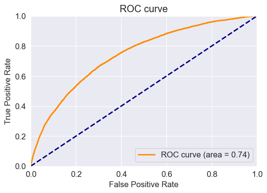

```python
def plot_roc(y_true,y_prob):
    fpr, tpr, _ = roc_curve(y_true, y_prob)
    roc_auc_value = roc_auc_score(y_true,y_prob)
    lw=2
    plt.figure(figsize=(6,4))
    plt.plot(fpr,tpr, color='darkorange',lw=lw,label='ROC curve (area = %0.2f)' %roc_auc_value)
    plt.plot([0,1],[0,1], color='navy',lw=lw,linestyle='--')
    plt.xlim([0,1])
    plt.ylim([0,1])
    plt.xlabel('False Positive Rate')
    plt.ylabel('True Positive Rate')
    plt.title('ROC curve')
    plt.legend(loc='lower right')
    plt.show()

plot_roc(y_test, best_model_probs)
```

#### The Precision-Recall Curve

```
   * ROC curve: The ROC curve plots the true positive rate vs. the false rositive sate

	  * The area under the curve (AUC): A value between 0.5 (random) and 1.0 (perfect), measuring the prediction accuracy

   * Recall (R) = The number of true positives / (the number of true positives + the number of false negatives)
```

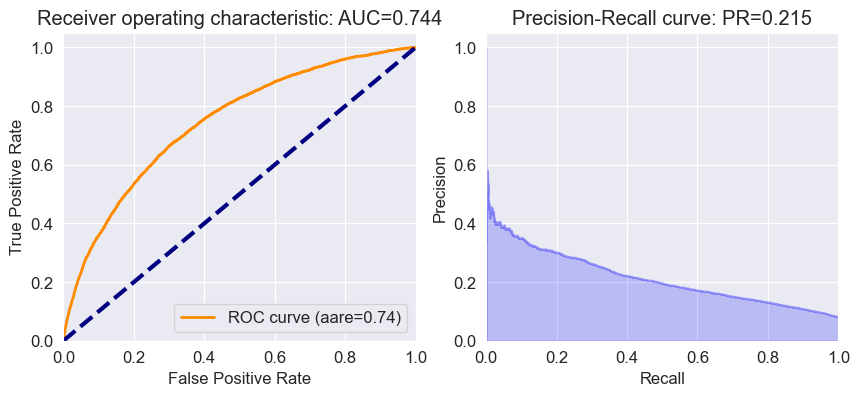

```python
from sklearn.metrics import roc_curve, auc, average_precision_score, precision_recall_curve

def ROC_PR(y_actual, y_pred):
    # ROC
    fpr = list()
    tpr = list()
    roc_auc = list()
    fpr,tpr,_ = roc_curve(y_actual,y_pred)
    roc_auc = auc(fpr,tpr)

    # Precision-Recall
    average_precision = average_precision_score(y_actual,y_pred)

    print('')
    print('   * ROC curve: The ROC curve plots the true positive rate vs. the false rositive sate')
    print('')
    print('	  * The area under the curve (AUC): A value between 0.5 (random) and 1.0 (perfect), measuring the prediction accuracy')
    print('')
    print('   * Recall (R) = The number of true positives / (the number of true positives + the number of false negatives)')
    print('')

    # plotting
    plt.figure(figsize=(10,4))

    # ROC
    plt.subplot(1,2,1)
    plt.plot(fpr,tpr,color='darkorange',lw=2,label='ROC curve (aare=%0.2f)' % roc_auc)
    plt.plot([0,1],[0,1],color='navy',lw=3,linestyle='--')
    plt.xlim([0.0,1.0])
    plt.ylim([0.0,1.05])
    plt.xlabel('False Positive Rate')
    plt.ylabel('True Positive Rate')
    plt.title('Receiver operating characteristic: AUC={0:0.3f}'.format(roc_auc))
    plt.legend(loc='lower right')

    # Precision-Recall
    plt.subplot(1,2,2)
    precision,recall,_ = precision_recall_curve(y_actual,y_pred)
    plt.step(recall,precision,color='b',alpha=0.2,where='post')
    plt.fill_between(recall,precision,step='post',alpha=0.2,color='b')
    plt.xlabel('Recall')
    plt.ylabel('Precision')
    plt.ylim([0.0,1.05])
    plt.xlim([0.0,1.0])
    plt.title('Precision-Recall curve: PR={0:0.3f}'.format(average_precision))
    plt.show()

ROC_PR(y_test,best_model_probs)
```

#### The F1 Score

```python
from sklearn.metrics import f1_score
# Calculate the F1 score
f1 = f1_score(y_test, best_model_pred)  # y_test is the actual, test_pred is the prediction
print("F1 Score:", f1)
```

```
F1 Score: 0.28393768817908105
```

#### The gains table

```python
def gains_table_profit(Y_test,y_pred):
    df_prep = pd.DataFrame(columns = ['actual','pred'])
    df_prep['actual'] = Y_test.values
    df_prep['pred'] =y_pred.values
    df_prep = df_prep.sort_values(by='pred',ascending=False)
    df_prep['row_id'] = range(0,0+len(df_prep))
    df_prep.head()

    df_prep['decile'] = (df_prep['row_id'] / (len(df_prep)/10)).astype(int)
    df_prep.loc[df_prep['decile'] == 10] =9
    df_prep['decile'].value_counts()

    # Create gains table
    gains = df_prep.groupby('decile')['actual'].agg(['count','sum'])
    gains.columns = ['count','actual']
    gains

    gains['non_actual'] = gains['count'] - gains['actual']
    gains['cum_count'] = gains['count'].cumsum()
    gains['cum_actual'] = gains['actual'].cumsum()
    gains['cum_non_actual'] = gains['non_actual'].cumsum()
    gains['percent_cum_actual'] = (gains['cum_actual'] / np.max(gains['cum_actual'])).round(2)
    gains['percent_cum_non_actual'] = (gains['cum_non_actual'] / np.max(gains['cum_non_actual'])).round(2)
    gains['if_random'] = np.max(gains['cum_actual']) /10
    gains['if_random'] = gains['if_random'].cumsum()
    gains['lift'] = (gains['cum_actual'] / gains['if_random']).round(2)
    gains['K_S'] = np.abs( gains['percent_cum_actual'] - gains['percent_cum_non_actual']  ) * 100
    gains['gain'] = (gains['cum_actual'] / gains['cum_count']*100).round(2)
    gains['revenue'] = approved_load * irr *  gains['non_actual']
    gains['cost'] = approved_load *  gains['actual']
    gains['profit'] = gains['revenue'] - gains['cost']
    return(gains)

# Assume the following values
approved_load = 10000
irr = 0.10 # annual interest rate

best_gains = gains_table_profit(y_test,best_model_probs)
best_gains
```

| decile | count | actual | non_actual | cum_count | cum_actual | cum_non_actual | percent_cum_actual | percent_cum_non_actual | if_random | lift | K_S | gain | revenue | cost | profit |
| --- | --- | --- | --- | --- | --- | --- | --- | --- | --- | --- | --- | --- | --- | --- | --- |
| 0 | 7688 | 1952 | 5736 | 7688 | 1952 | 5736 | 0.32 | 0.08 | 609.1 | 3.20 | 24.0 | 25.39 | 5736000.0 | 19520000 | -13784000.0 |
| 1 | 7688 | 1070 | 6618 | 15376 | 3022 | 12354 | 0.50 | 0.17 | 1218.2 | 2.48 | 33.0 | 19.65 | 6618000.0 | 10700000 | -4082000.0 |
| 2 | 7688 | 821 | 6867 | 23064 | 3843 | 19221 | 0.63 | 0.27 | 1827.3 | 2.10 | 36.0 | 16.66 | 6867000.0 | 8210000 | -1343000.0 |
| 3 | 7688 | 598 | 7090 | 30752 | 4441 | 26311 | 0.73 | 0.37 | 2436.4 | 1.82 | 36.0 | 14.44 | 7090000.0 | 5980000 | 1110000.0 |
| 4 | 7687 | 499 | 7188 | 38439 | 4940 | 33499 | 0.81 | 0.47 | 3045.5 | 1.62 | 34.0 | 12.85 | 7188000.0 | 4990000 | 2198000.0 |
| 5 | 7688 | 355 | 7333 | 46127 | 5295 | 40832 | 0.87 | 0.58 | 3654.6 | 1.45 | 29.0 | 11.48 | 7333000.0 | 3550000 | 3783000.0 |
| 6 | 7688 | 293 | 7395 | 53815 | 5588 | 48227 | 0.92 | 0.68 | 4263.7 | 1.31 | 24.0 | 10.38 | 7395000.0 | 2930000 | 4465000.0 |
| 7 | 7688 | 238 | 7450 | 61503 | 5826 | 55677 | 0.96 | 0.79 | 4872.8 | 1.20 | 17.0 | 9.47 | 7450000.0 | 2380000 | 5070000.0 |
| 8 | 7688 | 145 | 7543 | 69191 | 5971 | 63220 | 0.98 | 0.89 | 5481.9 | 1.09 | 9.0 | 8.63 | 7543000.0 | 1450000 | 6093000.0 |
| 9 | 7687 | 120 | 7567 | 76878 | 6091 | 70787 | 1.00 | 1.00 | 6091.0 | 1.00 | 0.0 | 7.92 | 7567000.0 | 1200000 | 6367000.0 |

#### The cumulative lift curve

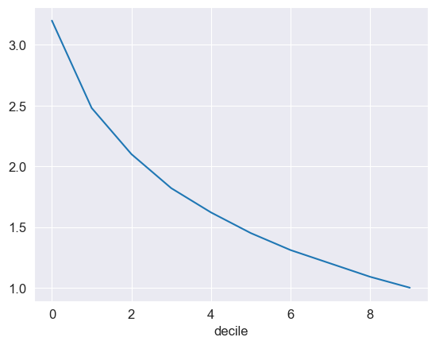

```python
# For your decision tree model, provide the code for the cumulative lift curve for the test data

best_gains['lift'].plot.line()
plt.show()
```

#### The Kolmogorov-Smirnov (K-S) statistic

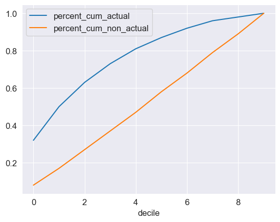

```python
best_gains[['percent_cum_actual','percent_cum_non_actual']].plot.line()
plt.show()
```

## (6) Profit & Loss Calculations (P&L)

Assumptions

- Each approved loan is worth $10,000.
- Approved loans have an annual interest rate of 10%, generating $1,000 in revenue per loan per year.
- If a loan defaults, the bank loses the entire loan amount ($10,000).

Profit calculation:

- If a loan is approved and does not default, the bank gains $1,000 in interest revenue.
- If a loan is approved and defaults, the bank loses $10,000.
- Calculate the overall profit or loss across the test dataset.
- Total Revenue: Sum of gains from approved loans that do not default.
- Total Loss: Sum of losses from approved loans that default.
- Net Profit: Total Revenue - Total Loss.

What we can do:

```python
# Assume the following values

irr = 0.05 # annual interest rate
sensitivity = gains_table_profit(y_test,best_model_probs)
selected_profit = sensitivity[sensitivity['profit']>0]['profit'].sum()
print('The profits from the positive profit deciles is:', selected_profit)
sensitivity
```

```
The profits from the positive profit deciles is: 7134000.0
```

| decile | count | actual | non_actual | cum_count | cum_actual | cum_non_actual | percent_cum_actual | percent_cum_non_actual | if_random | lift | K_S | gain | revenue | cost | profit |
| --- | --- | --- | --- | --- | --- | --- | --- | --- | --- | --- | --- | --- | --- | --- | --- |
| 0 | 7688 | 1952 | 5736 | 7688 | 1952 | 5736 | 0.32 | 0.08 | 609.1 | 3.20 | 24.0 | 25.39 | 2868000.0 | 19520000 | -16652000.0 |
| 1 | 7688 | 1070 | 6618 | 15376 | 3022 | 12354 | 0.50 | 0.17 | 1218.2 | 2.48 | 33.0 | 19.65 | 3309000.0 | 10700000 | -7391000.0 |
| 2 | 7688 | 821 | 6867 | 23064 | 3843 | 19221 | 0.63 | 0.27 | 1827.3 | 2.10 | 36.0 | 16.66 | 3433500.0 | 8210000 | -4776500.0 |
| 3 | 7688 | 598 | 7090 | 30752 | 4441 | 26311 | 0.73 | 0.37 | 2436.4 | 1.82 | 36.0 | 14.44 | 3545000.0 | 5980000 | -2435000.0 |
| 4 | 7687 | 499 | 7188 | 38439 | 4940 | 33499 | 0.81 | 0.47 | 3045.5 | 1.62 | 34.0 | 12.85 | 3594000.0 | 4990000 | -1396000.0 |
| 5 | 7688 | 355 | 7333 | 46127 | 5295 | 40832 | 0.87 | 0.58 | 3654.6 | 1.45 | 29.0 | 11.48 | 3666500.0 | 3550000 | 116500.0 |
| 6 | 7688 | 293 | 7395 | 53815 | 5588 | 48227 | 0.92 | 0.68 | 4263.7 | 1.31 | 24.0 | 10.38 | 3697500.0 | 2930000 | 767500.0 |
| 7 | 7688 | 238 | 7450 | 61503 | 5826 | 55677 | 0.96 | 0.79 | 4872.8 | 1.20 | 17.0 | 9.47 | 3725000.0 | 2380000 | 1345000.0 |
| 8 | 7688 | 145 | 7543 | 69191 | 5971 | 63220 | 0.98 | 0.89 | 5481.9 | 1.09 | 9.0 | 8.63 | 3771500.0 | 1450000 | 2321500.0 |
| 9 | 7687 | 120 | 7567 | 76878 | 6091 | 70787 | 1.00 | 1.00 | 6091.0 | 1.00 | 0.0 | 7.92 | 3783500.0 | 1200000 | 2583500.0 |

```python
irr = 0.10 # annual interest rate
sensitivity = gains_table_profit(y_test,best_model_probs)
selected_profit = sensitivity[sensitivity['profit']>0]['profit'].sum()
print('The profits from the positive profit deciles is:', selected_profit)
sensitivity
```

```
The profits from the positive profit deciles is: 29086000.0
```

| decile | count | actual | non_actual | cum_count | cum_actual | cum_non_actual | percent_cum_actual | percent_cum_non_actual | if_random | lift | K_S | gain | revenue | cost | profit |
| --- | --- | --- | --- | --- | --- | --- | --- | --- | --- | --- | --- | --- | --- | --- | --- |
| 0 | 7688 | 1952 | 5736 | 7688 | 1952 | 5736 | 0.32 | 0.08 | 609.1 | 3.20 | 24.0 | 25.39 | 5736000.0 | 19520000 | -13784000.0 |
| 1 | 7688 | 1070 | 6618 | 15376 | 3022 | 12354 | 0.50 | 0.17 | 1218.2 | 2.48 | 33.0 | 19.65 | 6618000.0 | 10700000 | -4082000.0 |
| 2 | 7688 | 821 | 6867 | 23064 | 3843 | 19221 | 0.63 | 0.27 | 1827.3 | 2.10 | 36.0 | 16.66 | 6867000.0 | 8210000 | -1343000.0 |
| 3 | 7688 | 598 | 7090 | 30752 | 4441 | 26311 | 0.73 | 0.37 | 2436.4 | 1.82 | 36.0 | 14.44 | 7090000.0 | 5980000 | 1110000.0 |
| 4 | 7687 | 499 | 7188 | 38439 | 4940 | 33499 | 0.81 | 0.47 | 3045.5 | 1.62 | 34.0 | 12.85 | 7188000.0 | 4990000 | 2198000.0 |
| 5 | 7688 | 355 | 7333 | 46127 | 5295 | 40832 | 0.87 | 0.58 | 3654.6 | 1.45 | 29.0 | 11.48 | 7333000.0 | 3550000 | 3783000.0 |
| 6 | 7688 | 293 | 7395 | 53815 | 5588 | 48227 | 0.92 | 0.68 | 4263.7 | 1.31 | 24.0 | 10.38 | 7395000.0 | 2930000 | 4465000.0 |
| 7 | 7688 | 238 | 7450 | 61503 | 5826 | 55677 | 0.96 | 0.79 | 4872.8 | 1.20 | 17.0 | 9.47 | 7450000.0 | 2380000 | 5070000.0 |
| 8 | 7688 | 145 | 7543 | 69191 | 5971 | 63220 | 0.98 | 0.89 | 5481.9 | 1.09 | 9.0 | 8.63 | 7543000.0 | 1450000 | 6093000.0 |
| 9 | 7687 | 120 | 7567 | 76878 | 6091 | 70787 | 1.00 | 1.00 | 6091.0 | 1.00 | 0.0 | 7.92 | 7567000.0 | 1200000 | 6367000.0 |

```python
irr = 0.12 # annual interest rate
sensitivity = gains_table_profit(y_test,best_model_probs)
selected_profit = sensitivity[sensitivity['profit']>0]['profit'].sum()
print('The profits from the positive profit deciles is:', selected_profit)
sensitivity
```

```
The profits from the positive profit deciles is: 39429600.0
```

| decile | count | actual | non_actual | cum_count | cum_actual | cum_non_actual | percent_cum_actual | percent_cum_non_actual | if_random | lift | K_S | gain | revenue | cost | profit |
| --- | --- | --- | --- | --- | --- | --- | --- | --- | --- | --- | --- | --- | --- | --- | --- |
| 0 | 7688 | 1952 | 5736 | 7688 | 1952 | 5736 | 0.32 | 0.08 | 609.1 | 3.20 | 24.0 | 25.39 | 6883200.0 | 19520000 | -12636800.0 |
| 1 | 7688 | 1070 | 6618 | 15376 | 3022 | 12354 | 0.50 | 0.17 | 1218.2 | 2.48 | 33.0 | 19.65 | 7941600.0 | 10700000 | -2758400.0 |
| 2 | 7688 | 821 | 6867 | 23064 | 3843 | 19221 | 0.63 | 0.27 | 1827.3 | 2.10 | 36.0 | 16.66 | 8240400.0 | 8210000 | 30400.0 |
| 3 | 7688 | 598 | 7090 | 30752 | 4441 | 26311 | 0.73 | 0.37 | 2436.4 | 1.82 | 36.0 | 14.44 | 8508000.0 | 5980000 | 2528000.0 |
| 4 | 7687 | 499 | 7188 | 38439 | 4940 | 33499 | 0.81 | 0.47 | 3045.5 | 1.62 | 34.0 | 12.85 | 8625600.0 | 4990000 | 3635600.0 |
| 5 | 7688 | 355 | 7333 | 46127 | 5295 | 40832 | 0.87 | 0.58 | 3654.6 | 1.45 | 29.0 | 11.48 | 8799600.0 | 3550000 | 5249600.0 |
| 6 | 7688 | 293 | 7395 | 53815 | 5588 | 48227 | 0.92 | 0.68 | 4263.7 | 1.31 | 24.0 | 10.38 | 8874000.0 | 2930000 | 5944000.0 |
| 7 | 7688 | 238 | 7450 | 61503 | 5826 | 55677 | 0.96 | 0.79 | 4872.8 | 1.20 | 17.0 | 9.47 | 8940000.0 | 2380000 | 6560000.0 |
| 8 | 7688 | 145 | 7543 | 69191 | 5971 | 63220 | 0.98 | 0.89 | 5481.9 | 1.09 | 9.0 | 8.63 | 9051600.0 | 1450000 | 7601600.0 |
| 9 | 7687 | 120 | 7567 | 76878 | 6091 | 70787 | 1.00 | 1.00 | 6091.0 | 1.00 | 0.0 | 7.92 | 9080400.0 | 1200000 | 7880400.0 |